# Week 11: Text mining

MTH 365: Introduction to Data Science

October 30, 2023

```r
library(tidyverse)
library(tidytext)
library(textdata)
```

## Recommended Reading

- *Text Mining with R* (https://www.tidytextmining.com/)

Text data is one of the most common type of data in the modern world. Usually, it is much more complicated that the numerical data thus we need to pre-process the data before we use it.

## Game of Thrones Twitter data

Following a data set that captures the release of all six Game of Thrones episodes from the eighth season that premiered on 14th of April, 2019 (https://www.kaggle.com/datasets/monogenea/game-of-thrones-twitter). We will briefly cover web scraping at the end of this course.

```r
got <- read.csv("got_tweets.csv")
glimpse(got)
```

```
## Rows: 21,209
## Columns: 11
## $ X              <int> 1, 2, 3, 4, 5, 6, 7, 8, 9, 10, 11, 12, 13, 14, 15, 16, …
## $ user_id        <chr> "x18838558", "x37622459", "x37622459", "x1522651170", "…
## $ created_at     <chr> "2019-04-17 06:06:33", "2019-04-17 05:57:10", "2019-04-…
## $ screen_name    <chr> "shannonwoodward", "TonyBakercomedy", "TonyBakercomedy"…
## $ text           <chr> "Someone asked me today, “who are you in Game Of Throne…
## $ favorite_count <int> 35, 19, 60, 13, 13, 24, 11, 14, 11, 54, 63, 13, 1431, 2…
## $ retweet_count  <int> 3, 0, 1, 1, 1, 7, 0, 0, 0, 1, 1, 0, 76, 1, 1, 11, 0, 0,…
## $ hashtags       <chr> "", "", "", "", "", "sansa SansaStark ForTheThrone quee…
## $ lang           <chr> "en", "en", "en", "en", "en", "en", "en", "en", "en", "…
## $ location       <chr> "LA/NY", "Behind U. Ha! Made U look. L.A", "Behind U. H…
## $ profile_url    <chr> "", "http://t.co/neAiEFv6lY", "http://t.co/neAiEFv6lY",…
```

Even though it is always exciting to work with the social media data, its messiness can make the analysis hard. It usually has a lot of missing data and text data is free of format.

Let’s first focus on the tweet text itself and think about if we can create some variables that are easier to analysis from the text.

However, before we extract the information, we need to convert all the text to lower cases (or upper if you preferred)

```r
got$lowertext = tolower(got$text)
glimpse(got)
```

```
## Rows: 21,209
## Columns: 12
## $ X              <int> 1, 2, 3, 4, 5, 6, 7, 8, 9, 10, 11, 12, 13, 14, 15, 16, …
## $ user_id        <chr> "x18838558", "x37622459", "x37622459", "x1522651170", "…
## $ created_at     <chr> "2019-04-17 06:06:33", "2019-04-17 05:57:10", "2019-04-…
## $ screen_name    <chr> "shannonwoodward", "TonyBakercomedy", "TonyBakercomedy"…
## $ text           <chr> "Someone asked me today, “who are you in Game Of Throne…
## $ favorite_count <int> 35, 19, 60, 13, 13, 24, 11, 14, 11, 54, 63, 13, 1431, 2…
## $ retweet_count  <int> 3, 0, 1, 1, 1, 7, 0, 0, 0, 1, 1, 0, 76, 1, 1, 11, 0, 0,…
## $ hashtags       <chr> "", "", "", "", "", "sansa SansaStark ForTheThrone quee…
## $ lang           <chr> "en", "en", "en", "en", "en", "en", "en", "en", "en", "…
## $ location       <chr> "LA/NY", "Behind U. Ha! Made U look. L.A", "Behind U. H…
## $ profile_url    <chr> "", "http://t.co/neAiEFv6lY", "http://t.co/neAiEFv6lY",…
## $ lowertext      <chr> "someone asked me today, “who are you in game of throne…
```

### Convert the text to Yes/No question

Suppose, we want to know whether certain words in the text may increase the retweet. Recall the str_detect function in the previous labs. (The `stringr` package is a common package used for text data).

```r
got = got %>%
  mutate(isWatch = str_detect(lowertext, "watch"))
table(got$isWatch)
```

```
##
## FALSE  TRUE
## 15697  5512
```

```r
got = got %>%
  mutate(isWinter = str_detect(lowertext, "winter"))
table(got$isWinter)
```

```
##
## FALSE  TRUE
## 20907   302
```

We can also look for a specific punctuation.

```r
got = got %>%
  mutate(isHash = str_detect(lowertext, "#"))
table(got$isHash)
```

```
##
## FALSE  TRUE
## 19551  1658
```

We can even count how many hashtag in each text.

```r
got = got %>%
  mutate(NumHash = str_count(lowertext, "#"))
table(got$NumHash)
```

```
##
##     0     1     2     3     4     5     6     7     8     9    10    11
## 19551  1143   328    97    45    20    11     5     2     4     2     1
```

There are some other basic information you can extract, like the length of the text

```r
got = got %>%
  mutate(length = str_length(lowertext))
summary(got$length)
```

```
##    Min. 1st Qu.  Median    Mean 3rd Qu.    Max.
##    15.0    75.0   108.0   120.1   154.0   280.0
```

### Parts of Speech

You can also do something fancy (but will take much longer time to run). For example, we can generate the part-of-speech tags for the words in the text and count how many noun/verb in the text. It will be better to use the text without lower case transformation in the following detection.

```r
library(udpipe)

detect_ps = function(text){
  tokens = udpipe::udpipe(text, "english")
  NumNoun = tokens %>% filter(upos == "PROPN") %>% summarise(N = n()) %>% pull()
  NumVerb = tokens %>% filter(upos == "VERB") %>% summarise(N = n()) %>% pull()
  return(c(NumNoun, NumVerb))
}

detect_ps("
I can’t stop humming the Game of Thrones theme music")
```

```
## [1] 1 2
```

```r
result = sapply(got$text[1:100], detect_ps)

got_sub = got[1:100,] %>%
  mutate(numNoun = result[1,],
         numVerb = result[2,])

glimpse(got_sub)
```

```
## Rows: 100
## Columns: 19
## $ X              <int> 1, 2, 3, 4, 5, 6, 7, 8, 9, 10, 11, 12, 13, 14, 15, 16, …
## $ user_id        <chr> "x18838558", "x37622459", "x37622459", "x1522651170", "…
## $ created_at     <chr> "2019-04-17 06:06:33", "2019-04-17 05:57:10", "2019-04-…
## $ screen_name    <chr> "shannonwoodward", "TonyBakercomedy", "TonyBakercomedy"…
## $ text           <chr> "Someone asked me today, “who are you in Game Of Throne…
## $ favorite_count <int> 35, 19, 60, 13, 13, 24, 11, 14, 11, 54, 63, 13, 1431, 2…
## $ retweet_count  <int> 3, 0, 1, 1, 1, 7, 0, 0, 0, 1, 1, 0, 76, 1, 1, 11, 0, 0,…
## $ hashtags       <chr> "", "", "", "", "", "sansa SansaStark ForTheThrone quee…
## $ lang           <chr> "en", "en", "en", "en", "en", "en", "en", "en", "en", "…
## $ location       <chr> "LA/NY", "Behind U. Ha! Made U look. L.A", "Behind U. H…
## $ profile_url    <chr> "", "http://t.co/neAiEFv6lY", "http://t.co/neAiEFv6lY",…
## $ lowertext      <chr> "someone asked me today, “who are you in game of throne…
## $ isWatch        <lgl> FALSE, TRUE, TRUE, FALSE, FALSE, FALSE, FALSE, FALSE, F…
## $ isWinter       <lgl> FALSE, FALSE, FALSE, FALSE, FALSE, FALSE, FALSE, FALSE,…
## $ isHash         <lgl> FALSE, FALSE, FALSE, FALSE, FALSE, TRUE, FALSE, FALSE, …
## $ NumHash        <int> 0, 0, 0, 0, 0, 5, 0, 0, 0, 0, 0, 0, 0, 0, 0, 0, 0, 0, 0…
## $ length         <int> 144, 164, 197, 153, 61, 137, 117, 89, 58, 167, 207, 52,…
## $ numNoun        <int> 1, 4, 2, 1, 0, 13, 0, 0, 0, 1, 0, 1, 0, 4, 0, 1, 4, 0, …
## $ numVerb        <int> 2, 4, 5, 3, 0, 0, 1, 2, 0, 4, 6, 1, 3, 2, 3, 4, 1, 2, 0…
```

Other techinques like NER (Named entity recognition) can identify whether there is a Human name/Place in the text. See the tutorial if you are interested: https://rstudio-pubs-static.s3.amazonaws.com/230718_6d29404ebb2a444fa0d218917dd1ec67.html

### Sentimental analysis

Words has meaning, thus an emotion can be associated with each word, and the text. Sentimental score is usually a number. If it is positive, it indicates the word/sentence has a positive meaning and vice versa. The scale for sentiment scores using the `syuzhet` method is a decimal and ranges from -1 (most negative) to +1 (most positive). If have a line of text, the function returns the sum of all the sentiment scores of meaningful words.

```r
library(syuzhet)

get_sentiment("happy", method = "syuzhet")
```

```
## [1] 0.75
```

```r
get_sentiment("sad", method = "syuzhet")
```

```
## [1] -0.5
```

```r
get_sentiment("It was a nice day even though I lost the game. ", method = "syuzhet")
```

```
## [1] -0.25
```

```r
got$syuzhet = get_sentiment(got$text,
                              method = "syuzhet")
summary(got$syuzhet)
```

```
##    Min. 1st Qu.  Median    Mean 3rd Qu.    Max.
## -4.9000 -0.2500  0.0000  0.1515  0.7000  5.8000
```

### Try by yourself

Following is a sample IMDB people data.

```r
imdb= read.csv("imdb.csv")
glimpse(imdb)
```

```
## Rows: 1,000
## Columns: 6
## $ nconst            <chr> "nm0000001", "nm0000002", "nm0000003", "nm0000004", …
## $ primaryName       <chr> "Fred Astaire", "Lauren Bacall", "Brigitte Bardot", …
## $ birthYear         <int> 1899, 1924, 1934, 1949, 1918, 1915, 1899, 1924, 1925…
## $ deathYear         <int> 1987, 2014, NA, 1982, 2007, 1982, 1957, 2004, 1984, …
## $ primaryProfession <chr> "soundtrack,actor,miscellaneous", "actress,soundtrac…
## $ knownForTitles    <chr> "tt0031983,tt0072308,tt0053137,tt0050419", "tt003835…
```

Create some other variables based on this data: 1. Whether the person is an actor 2. How many profession that each person has 3. Whether the person is still alive

```r
imdb = imdb %>%
  mutate(isActor = str_detect(primaryProfession, "actor"))
table(imdb$isActor)
```

```
##
## FALSE  TRUE
##   513   487
```

```r
imdb = imdb %>%
  mutate(Numpro = str_count(primaryProfession, ",")+1)
table(imdb$Numpro)
```

```
##
##   1   2   3
##  63 154 783
```

```r
imdb = imdb %>%
  mutate(isAlive = !is.na(deathYear))
table(imdb$isAlive)
```

```
##
## FALSE  TRUE
##   712   288
```

### Clean the categorical levels

Sometimes we need to clean the data to generate a data that easier for analysis. Suppose now we only take everyone’s first profession. We can find patterns in the data using regular expressions (https://www.datacamp.com/tutorial/regex-r-regular-expressions-guide)

```r
imdb$firstPro = gsub(",.*", "", imdb$primaryProfession)

head(imdb)
```

```
##      nconst     primaryName birthYear deathYear
## 1 nm0000001    Fred Astaire      1899      1987
## 2 nm0000002   Lauren Bacall      1924      2014
## 3 nm0000003 Brigitte Bardot      1934        NA
## 4 nm0000004    John Belushi      1949      1982
## 5 nm0000005  Ingmar Bergman      1918      2007
## 6 nm0000006  Ingrid Bergman      1915      1982
##                     primaryProfession                          knownForTitles
## 1      soundtrack,actor,miscellaneous tt0031983,tt0072308,tt0053137,tt0050419
## 2                  actress,soundtrack tt0038355,tt0071877,tt0037382,tt0117057
## 3 actress,soundtrack,music_department tt0049189,tt0057345,tt0056404,tt0054452
## 4             actor,soundtrack,writer tt0072562,tt0077975,tt0078723,tt0080455
## 5               writer,director,actor tt0050986,tt0083922,tt0060827,tt0069467
## 6         actress,soundtrack,producer tt0038109,tt0077711,tt0036855,tt0034583
##   isActor Numpro isAlive   firstPro
## 1    TRUE      3    TRUE soundtrack
## 2   FALSE      2    TRUE    actress
## 3   FALSE      3   FALSE    actress
## 4    TRUE      3    TRUE      actor
## 5    TRUE      3    TRUE     writer
## 6   FALSE      3    TRUE    actress
```

```r
table(imdb$firstPro)
```

```
##
##                                 actor            actress       art_director
##                  1                423                368                  1
## assistant_director    cinematographer           composer           director
##                  2                  6                  2                 51
##             editor make_up_department      miscellaneous   music_department
##                  3                  1                  3                 13
##           producer         soundtrack             writer
##                 40                 28                 58
```

```r
imdb = imdb %>% mutate(cleanPro = case_when(
  firstPro == "actor" | firstPro == "actress" ~ "act",
  str_detect(firstPro, "director") ~ "director",
  firstPro == "writer" | firstPro == "editor" ~ "write",
  firstPro == "producer" ~ "producer",
  TRUE ~ "other"
))
table(imdb$cleanPro)
```

```
##
##      act director    other producer    write
##      791       54       54       40       61
```

One more note: the date/time data can also be treated as the text data. You can choose to extract only the year/month from the complete timestamps.

### Summarize the text

Go back to our Game of Thrones example. Instead of generating new variables to fit the model, sometimes we just what to know what those text are about. Smart non-coding way includes generate a word cloud, which displays the most frequent words.

It is difficult to analyze a sentence of text. We can’t filter out words or count which occur most frequently since it is made up of multiple words. Hence, we need to covert it into *tokens*. - A *token* is a meaningful unit of text that can be used for further analysis.

We create tokens using the `unnest_tokens` function.

```r
tweet_words <- got %>%
  select(text) %>%
  unnest_tokens(word,text)

glimpse(tweet_words)
```

```
## Rows: 482,309
## Columns: 1
## $ word <chr> "someone", "asked", "me", "today", "who", "are", "you", "in", "ga…
```

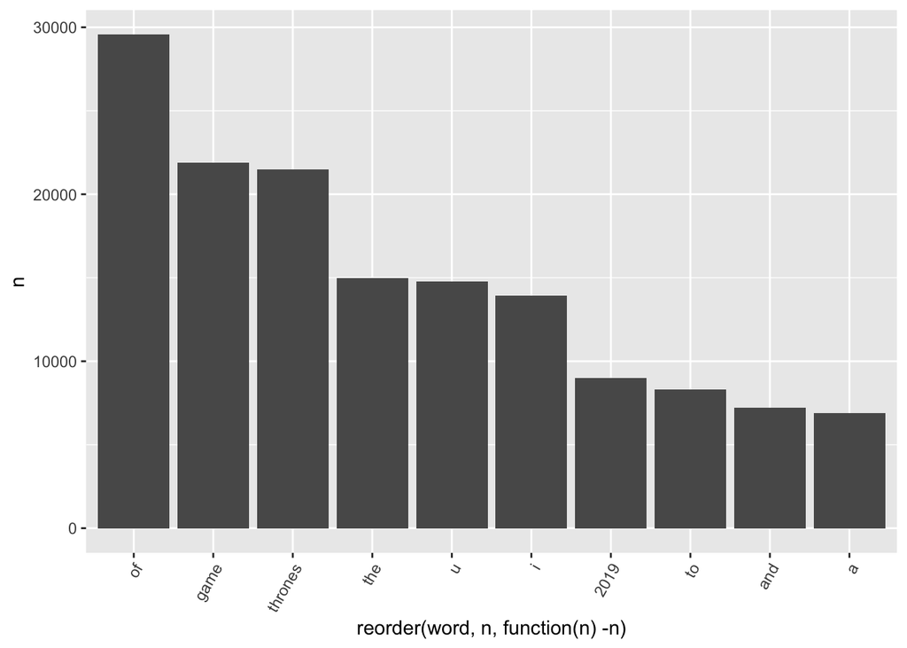

```r
top25 <- tweet_words %>% count(word,sort=T) %>% slice(1:10)

ggplot(top25,
       aes(x = reorder(word, n, function(n) -n), y = n)) +
  geom_bar(stat = "identity") +
  theme(axis.text.x = element_text(angle = 60, hjust = 1))
```

Stop words are words that does not have meaning in the text, like “the” and “a”.

```r
glimpse(stop_words)
```

```
## Rows: 1,149
## Columns: 2
## $ word    <chr> "a", "a's", "able", "about", "above", "according", "accordingl…
## $ lexicon <chr> "SMART", "SMART", "SMART", "SMART", "SMART", "SMART", "SMART",…
```

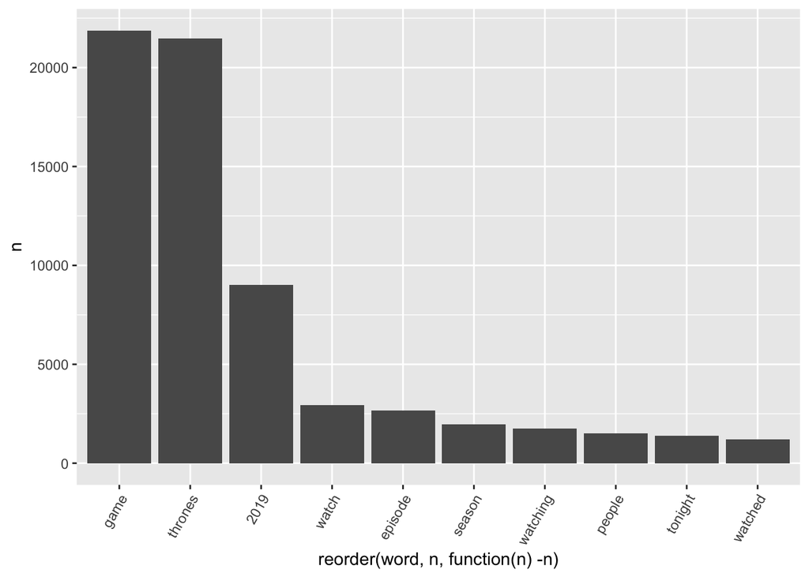

```r
my_stop_words <- stop_words %>% select(word) %>%
  bind_rows(data.frame(word = c("https", "t.co", "rt")))

tweet_words_interesting <- tweet_words %>% anti_join(my_stop_words)

tweet_words_interesting %>%
  group_by(word) %>%
  tally(sort=TRUE) %>%
  slice(1:10) %>%
  ggplot(aes(x = reorder(word, n, function(n) -n), y = n)) +
  geom_bar(stat = "identity") + theme(axis.text.x = element_text(angle = 60, hjust = 1))
```

You can also create a Word Cloud (only in html) - https://r-graph-gallery.com/196-the-wordcloud2-library.html

```r
library(wordcloud2)

t <- tweet_words_interesting %>%
  group_by(word) %>%
  tally(sort=TRUE) %>%
  filter(n > 500)

wordcloud2(data=t, size=1.6)
```

[interactive chart not shown]

You can also show the general trend of sentiments in all the words.

```r
#library(textdata)

nrc_lex <- get_sentiments("nrc")
fn_sentiment <- tweet_words_interesting %>% left_join(nrc_lex)
fn_sentiment %>% filter(!is.na(sentiment)) %>%
  group_by(sentiment) %>%
  summarise(n=n())
```

```
## # A tibble: 10 × 2
##    sentiment        n
##    <chr>        <int>
##  1 anger         5330
##  2 anticipation 11612
##  3 disgust       4618
##  4 fear          8187
##  5 joy           6400
##  6 negative     10829
##  7 positive     14242
##  8 sadness       5431
##  9 surprise      3385
## 10 trust         9214
```

```r
bing_lex <- get_sentiments("bing")
fn_sentiment <- tweet_words_interesting %>% left_join(bing_lex)
fn_sentiment %>% filter(!is.na(sentiment)) %>% group_by(sentiment) %>% summarise(n=n())
```

```
## # A tibble: 2 × 2
##   sentiment     n
##   <chr>     <int>
## 1 negative  11523
## 2 positive   8173
```